# CSP571_Project_Experimentation for Pennsylvania conventional home loans for 2014

# Model plots

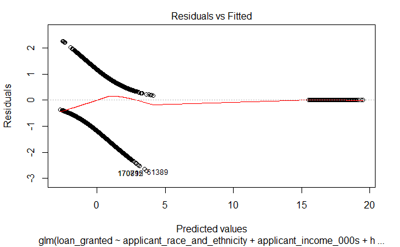

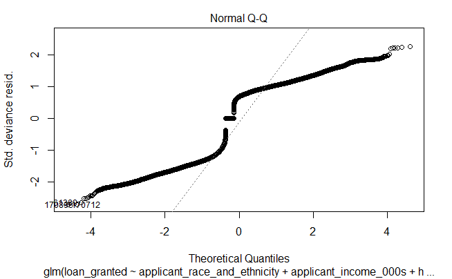

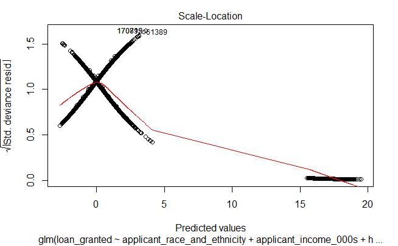

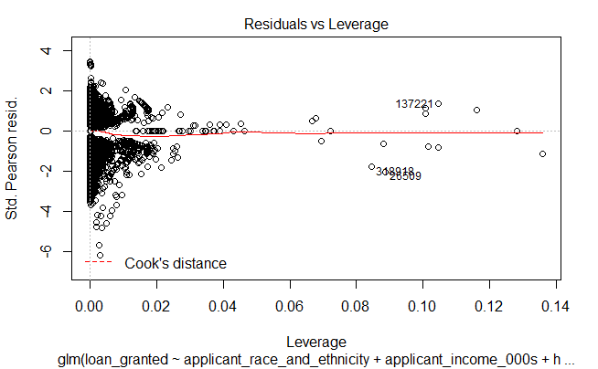

```r
plot(model)
```

# Model with log of loan amount and income.

```r
model_log_income_and_amount <- glm(loan_granted~applicant_race_and_ethnicity+log_applicant_income_000s+hoepa_status+lien_status+owner_occupancy+preapproval+property_type+log_loan_amount_000s+msamd+applicant_sex+county_code+hud_median_family_income+tract_to_msamd_income+co_applicant_present+agency_code+minority_population, family = binomial(link='logit'), data=train)

writeLines("Summary for log model is as below")
```

```
Summary for log model is as below
```

```r
writeLines("")
```

```r
summary(model_log_income_and_amount)
```

```
Call:
glm(formula = loan_granted ~ applicant_race_and_ethnicity + log_applicant_income_000s +
    hoepa_status + lien_status + owner_occupancy + preapproval +
    property_type + log_loan_amount_000s + msamd + applicant_sex +
    county_code + hud_median_family_income + tract_to_msamd_income +
    co_applicant_present + agency_code + minority_population,
    family = binomial(link = "logit"), data = train)

Deviance Residuals:
    Min       1Q   Median       3Q      Max
-2.4744  -1.1576   0.6760   0.9478   2.3987

Coefficients:
                                                                                                                Estimate
(Intercept)                                                                                                    1.596e+01
applicant_race_and_ethnicityAsian                                                                              6.442e-01
applicant_race_and_ethnicityBlack or African American                                                          2.080e-01
applicant_race_and_ethnicityHispanic or Latino                                                                 2.990e-01
applicant_race_and_ethnicityInformation not provided by applicant in mail, Internet, or telephone application  2.565e-01
applicant_race_and_ethnicityNative Hawaiian or Other Pacific Islander                                          4.849e-01
applicant_race_and_ethnicityNot applicable                                                                    -3.377e-01
applicant_race_and_ethnicityWhite                                                                              7.638e-01
log_applicant_income_000s                                                                                      3.058e-01
hoepa_status2                                                                                                 -1.713e+01
lien_status2                                                                                                  -3.135e-01
lien_status3                                                                                                  -5.086e-01
lien_status4                                                                                                   1.674e+01
owner_occupancy2                                                                                              -1.328e-01
owner_occupancy3                                                                                              -3.192e-02
preapproval2                                                                                                  -3.479e-02
preapproval3                                                                                                  -8.238e-01
property_type2                                                                                                -9.321e-01
property_type3                                                                                                -2.900e-01
log_loan_amount_000s                                                                                          -4.438e-02
msamd                                                                                                         -1.322e-05
applicant_sex2                                                                                                -1.307e-02
applicant_sex3                                                                                                 2.789e-02
applicant_sex4                                                                                                 1.927e+00
county_code3                                                                                                   4.262e-01
county_code5                                                                                                   2.105e-01
```

[output cut: 468 more lines]

```
agency_code3                                                                                                  ***
agency_code5                                                                                                  **
agency_code7                                                                                                  ***
agency_code9                                                                                                  ***
minority_population                                                                                           ***
---
Signif. codes:  0 ‘***’ 0.001 ‘**’ 0.01 ‘*’ 0.05 ‘.’ 0.1 ‘ ’ 1

(Dispersion parameter for binomial family taken to be 1)

    Null deviance: 336889  on 258228  degrees of freedom
Residual deviance: 294860  on 258130  degrees of freedom
AIC: 295058

Number of Fisher Scoring iterations: 16
```

```r
writeLines("Anova for log model is as below")
```

```
Anova for log model is as below
```

```r
writeLines("")
```

```r
anova(model_log_income_and_amount)
```

```
Analysis of Deviance Table

Model: binomial, link: logit

Response: loan_granted

Terms added sequentially (first to last)

                             Df Deviance Resid. Df Resid. Dev
NULL                                        258228     336889
applicant_race_and_ethnicity  7  17564.3    258221     319325
log_applicant_income_000s     1   4126.2    258220     315198
hoepa_status                  1     36.0    258219     315162
lien_status                   3  10928.3    258216     304234
owner_occupancy               2    178.6    258214     304055
preapproval                   2   2630.7    258212     301425
property_type                 2    728.9    258210     300696
log_loan_amount_000s          1    214.1    258209     300482
msamd                         1     15.0    258208     300467
applicant_sex                 3     67.6    258205     300399
county_code                  66   1597.5    258139     298802
hud_median_family_income      1      6.2    258138     298795
tract_to_msamd_income         1    217.6    258137     298578
co_applicant_present          1    377.3    258136     298201
agency_code                   5   3091.4    258131     295109
minority_population           1    249.3    258130     294860
```

# Model 2 with loan to income ratio.

```r
model_loan_income_ratio <- glm(loan_granted~applicant_race_and_ethnicity+applicant_income_000s+loan_to_income_ratio+co_applicant_present+co_applicant_sex+hoepa_status+lien_status+owner_occupancy+preapproval+property_type+loan_amount_000s+msamd+applicant_sex+county_code+hud_median_family_income+tract_to_msamd_income+agency_code+minority_population, family = binomial(link='logit'), data=train)
```

```
glm.fit: fitted probabilities numerically 0 or 1 occurred
```

```r
writeLines("Summary for model is as below")
```

```
Summary for model is as below
```

```r
writeLines("")
```

```r
summary(model_loan_income_ratio)
```

```
Call:
glm(formula = loan_granted ~ applicant_race_and_ethnicity + applicant_income_000s +
    loan_to_income_ratio + co_applicant_present + co_applicant_sex +
    hoepa_status + lien_status + owner_occupancy + preapproval +
    property_type + loan_amount_000s + msamd + applicant_sex +
    county_code + hud_median_family_income + tract_to_msamd_income +
    agency_code + minority_population, family = binomial(link = "logit"),
    data = train)

Deviance Residuals:
    Min       1Q   Median       3Q      Max
-2.7912  -1.1691   0.6842   0.9496   8.4904

Coefficients:
                                                                                                                Estimate
(Intercept)                                                                                                    1.702e+01
applicant_race_and_ethnicityAsian                                                                              6.636e-01
applicant_race_and_ethnicityBlack or African American                                                          1.901e-01
applicant_race_and_ethnicityHispanic or Latino                                                                 2.747e-01
applicant_race_and_ethnicityInformation not provided by applicant in mail, Internet, or telephone application  1.865e-01
applicant_race_and_ethnicityNative Hawaiian or Other Pacific Islander                                          4.829e-01
applicant_race_and_ethnicityNot applicable                                                                    -3.494e-01
applicant_race_and_ethnicityWhite                                                                              7.728e-01
applicant_income_000s                                                                                          4.163e-05
loan_to_income_ratio                                                                                          -4.679e-02
co_applicant_present1                                                                                         -5.127e-02
co_applicant_sex2                                                                                              1.883e-01
co_applicant_sex3                                                                                              9.308e-02
co_applicant_sex4                                                                                              8.525e-02
co_applicant_sex5                                                                                             -1.838e-01
hoepa_status2                                                                                                 -1.710e+01
lien_status2                                                                                                  -2.831e-01
lien_status3                                                                                                  -5.268e-01
lien_status4                                                                                                   1.736e+01
owner_occupancy2                                                                                              -4.986e-02
owner_occupancy3                                                                                               2.289e-02
preapproval2                                                                                                  -3.941e-02
preapproval3                                                                                                  -8.388e-01
property_type2                                                                                                -1.019e+00
property_type3                                                                                                -8.469e-02
```

[output cut: 494 more lines]

```
agency_code3                                                                                                  ***
agency_code5                                                                                                  **
agency_code7                                                                                                  ***
agency_code9                                                                                                  ***
minority_population                                                                                           ***
---
Signif. codes:  0 ‘***’ 0.001 ‘**’ 0.01 ‘*’ 0.05 ‘.’ 0.1 ‘ ’ 1

(Dispersion parameter for binomial family taken to be 1)

    Null deviance: 336889  on 258228  degrees of freedom
Residual deviance: 295728  on 258125  degrees of freedom
AIC: 295936

Number of Fisher Scoring iterations: 16
```

```r
writeLines("Anova for model is as below")
```

```
Anova for model is as below
```

```r
writeLines("")
```

```r
anova(model_loan_income_ratio)
```

[output not shown]

```
Analysis of Deviance Table

Model: binomial, link: logit

Response: loan_granted

Terms added sequentially (first to last)

                             Df Deviance Resid. Df Resid. Dev
NULL                                        258228     336889
applicant_race_and_ethnicity  7  17564.3    258221     319325
applicant_income_000s         1    363.5    258220     318961
loan_to_income_ratio          1    141.5    258219     318820
co_applicant_present          1   1391.6    258218     317428
co_applicant_sex              4   2019.6    258214     315408
hoepa_status                  1     33.3    258213     315375
lien_status                   3  10203.8    258210     305171
owner_occupancy               2    110.7    258208     305061
preapproval                   2   2937.5    258206     302123
property_type                 2   1083.4    258204     301040
loan_amount_000s              1     71.0    258203     300969
msamd                         1     13.7    258202     300955
applicant_sex                 3     19.6    258199     300935
county_code                  66   1319.4    258133     299616
hud_median_family_income      1      6.8    258132     299609
tract_to_msamd_income         1    628.8    258131     298980
agency_code                   5   2988.8    258126     295992
minority_population           1    263.2    258125     295728
```

# Model plots

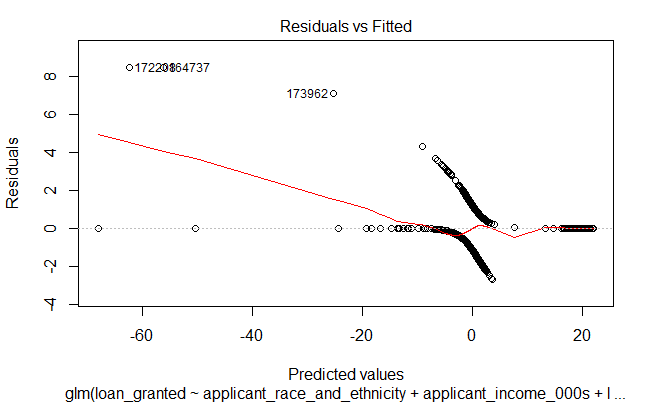

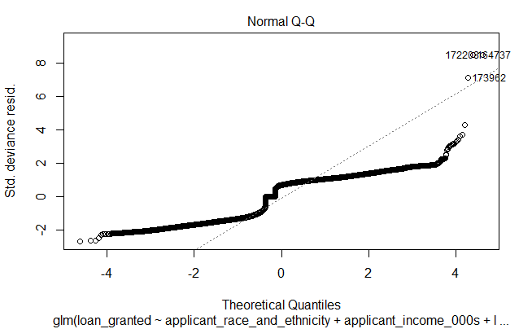

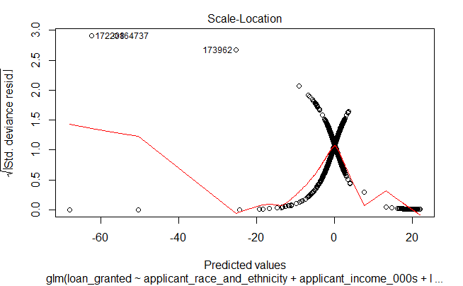

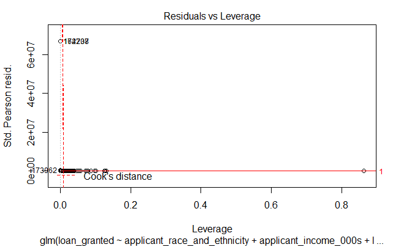

```r
plot(model_loan_income_ratio)
```

# Model 2 with log of loan amounts and income and loan to income ratio.

```r
model_log_amount_loan_income_ratio <- glm(loan_granted~applicant_race_and_ethnicity+log_applicant_income_000s+loan_to_income_ratio+co_applicant_present+co_applicant_sex+hoepa_status+lien_status+owner_occupancy+preapproval+property_type+log_loan_amount_000s+msamd+applicant_sex+county_code+hud_median_family_income+tract_to_msamd_income+agency_code+minority_population, family = binomial(link='logit'), data=train)

writeLines("Summary for log model with loan to income ratio is as below")
```

```
Summary for log model with loan to income ratio is as below
```

```r
writeLines("")
```

```r
summary(model_log_amount_loan_income_ratio)
```

```
Call:
glm(formula = loan_granted ~ applicant_race_and_ethnicity + log_applicant_income_000s +
    loan_to_income_ratio + co_applicant_present + co_applicant_sex +
    hoepa_status + lien_status + owner_occupancy + preapproval +
    property_type + log_loan_amount_000s + msamd + applicant_sex +
    county_code + hud_median_family_income + tract_to_msamd_income +
    agency_code + minority_population, family = binomial(link = "logit"),
    data = train)

Deviance Residuals:
    Min       1Q   Median       3Q      Max
-2.4691  -1.1580   0.6743   0.9472   3.2944

Coefficients:
                                                                                                                Estimate
(Intercept)                                                                                                    1.602e+01
applicant_race_and_ethnicityAsian                                                                              6.476e-01
applicant_race_and_ethnicityBlack or African American                                                          1.921e-01
applicant_race_and_ethnicityHispanic or Latino                                                                 2.966e-01
applicant_race_and_ethnicityInformation not provided by applicant in mail, Internet, or telephone application  1.639e-01
applicant_race_and_ethnicityNative Hawaiian or Other Pacific Islander                                          4.889e-01
applicant_race_and_ethnicityNot applicable                                                                    -4.216e-01
applicant_race_and_ethnicityWhite                                                                              7.629e-01
log_applicant_income_000s                                                                                      2.928e-01
loan_to_income_ratio                                                                                          -4.939e-03
co_applicant_present1                                                                                         -4.983e-02
co_applicant_sex2                                                                                              2.299e-01
co_applicant_sex3                                                                                              1.231e-01
co_applicant_sex4                                                                                              1.506e-01
co_applicant_sex5                                                                                             -6.001e-02
hoepa_status2                                                                                                 -1.713e+01
lien_status2                                                                                                  -3.090e-01
lien_status3                                                                                                  -4.920e-01
lien_status4                                                                                                   1.666e+01
owner_occupancy2                                                                                              -1.257e-01
owner_occupancy3                                                                                              -2.608e-02
preapproval2                                                                                                  -3.345e-02
preapproval3                                                                                                  -8.240e-01
property_type2                                                                                                -9.329e-01
property_type3                                                                                                -2.726e-01
```

[output cut: 494 more lines]

```
agency_code3                                                                                                  ***
agency_code5                                                                                                  **
agency_code7                                                                                                  ***
agency_code9                                                                                                  ***
minority_population                                                                                           ***
---
Signif. codes:  0 ‘***’ 0.001 ‘**’ 0.01 ‘*’ 0.05 ‘.’ 0.1 ‘ ’ 1

(Dispersion parameter for binomial family taken to be 1)

    Null deviance: 336889  on 258228  degrees of freedom
Residual deviance: 294645  on 258125  degrees of freedom
AIC: 294853

Number of Fisher Scoring iterations: 16
```

```r
writeLines("Anova for model is as below")
```

```
Anova for model is as below
```

```r
writeLines("")
```

```r
anova(model_log_amount_loan_income_ratio)
```

```
Analysis of Deviance Table

Model: binomial, link: logit

Response: loan_granted

Terms added sequentially (first to last)

                             Df Deviance Resid. Df Resid. Dev
NULL                                        258228     336889
applicant_race_and_ethnicity  7  17564.3    258221     319325
log_applicant_income_000s     1   4126.2    258220     315198
loan_to_income_ratio          1      0.1    258219     315198
co_applicant_present          1    443.2    258218     314755
co_applicant_sex              4   1802.9    258214     312952
hoepa_status                  1     36.0    258213     312916
lien_status                   3   9428.9    258210     303487
owner_occupancy               2    156.6    258208     303331
preapproval                   2   2729.0    258206     300602
property_type                 2    784.7    258204     299817
log_loan_amount_000s          1    135.3    258203     299682
msamd                         1     11.8    258202     299670
applicant_sex                 3     36.7    258199     299633
county_code                  66   1457.3    258133     298176
hud_median_family_income      1      6.2    258132     298170
tract_to_msamd_income         1    219.4    258131     297950
agency_code                   5   3059.8    258126     294890
minority_population           1    245.2    258125     294645
```

# Prediction based on the base model.

```r
# TODO
# Look into the rank-deficient fit warning here.
# Seems related to correlated predictors.
fitted.probs <- predict(model, test, type = "response")
```

# Compute statistics like classification errror, confusion matrix, etc based

# on our predictions.

```r
prediction_stats <- function(fitted.probs, test, threshold = 0.5) {
  fitted.results <- ifelse(fitted.probs > threshold, TRUE, FALSE)

  classification_error <- mean(fitted.results != test$loan_granted)
  classification_error

  print(paste('Accuracy', 1 - classification_error))

  print(confusionMatrix(as.factor(fitted.results), as.factor(test$loan_granted), positive = "TRUE"))
}
```

# Model performance.

```r
prediction_stats(fitted.probs, test)
```

```
[1] "Accuracy 0.684521965425367"
Confusion Matrix and Statistics

          Reference
Prediction FALSE  TRUE
     FALSE  7273  4523
     TRUE  15843 36917

               Accuracy : 0.6845
                 95% CI : (0.6809, 0.6881)
    No Information Rate : 0.6419
    P-Value [Acc > NIR] : < 2.2e-16

                  Kappa : 0.2304

 Mcnemar's Test P-Value : < 2.2e-16

            Sensitivity : 0.8909
            Specificity : 0.3146
         Pos Pred Value : 0.6997
         Neg Pred Value : 0.6166
             Prevalence : 0.6419
         Detection Rate : 0.5719
   Detection Prevalence : 0.8173
      Balanced Accuracy : 0.6027

       'Positive' Class : TRUE
```

# Plot TPR vs FPR

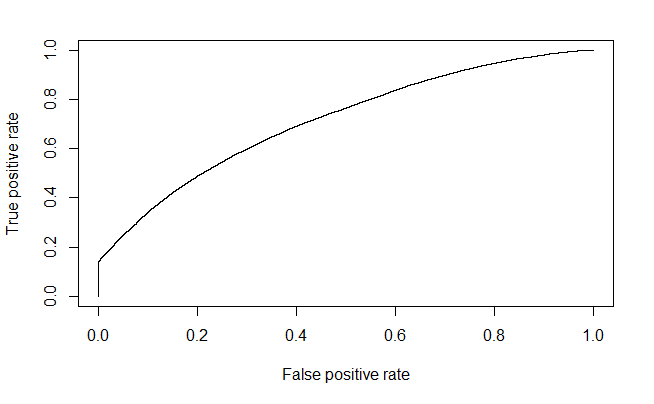

```r
library(ROCR)

#https://www.r-bloggers.com/evaluating-logistic-regression-models/#:~:text=K%2DFold%20Cross%20Validation&text=One%20such%20technique%20for%20doing,variable%20in%20our%20testing%20data.
pred <- prediction(fitted.probs, test$loan_granted)
perf <- performance(pred, measure = "tpr", x.measure = "fpr")
plot(perf)
```

# Prediction based on the model with loan to income ratio

```r
# TODO
# Look into the rank-deficient fit warning here.
# Seems related to correlated predictors.
fitted_2.probs <- predict(model_loan_income_ratio, test, type = "response")
```

# Model performance.

```r
prediction_stats(fitted_2.probs, test)
```

```
[1] "Accuracy 0.687527108247103"
Confusion Matrix and Statistics

          Reference
Prediction FALSE  TRUE
     FALSE  7318  4374
     TRUE  15798 37066

               Accuracy : 0.6875
                 95% CI : (0.6839, 0.6911)
    No Information Rate : 0.6419
    P-Value [Acc > NIR] : < 2.2e-16

                  Kappa : 0.2369

 Mcnemar's Test P-Value : < 2.2e-16

            Sensitivity : 0.8944
            Specificity : 0.3166
         Pos Pred Value : 0.7012
         Neg Pred Value : 0.6259
             Prevalence : 0.6419
         Detection Rate : 0.5742
   Detection Prevalence : 0.8189
      Balanced Accuracy : 0.6055

       'Positive' Class : TRUE
```

# Prediction based on the model with log income and loan to income ratio

```r
# TODO
# Look into the rank-deficient fit warning here.
# Seems related to correlated predictors.

fitted_2_log_income.probs <- predict(model_log_amount_loan_income_ratio, test, type = "response")
```

# Model performance.

```r
prediction_stats(fitted_2_log_income.probs, test)
```

```
[1] "Accuracy 0.690253423384348"
Confusion Matrix and Statistics

          Reference
Prediction FALSE  TRUE
     FALSE  7635  4515
     TRUE  15481 36925

               Accuracy : 0.6903
                 95% CI : (0.6867, 0.6938)
    No Information Rate : 0.6419
    P-Value [Acc > NIR] : < 2.2e-16

                  Kappa : 0.2473

 Mcnemar's Test P-Value : < 2.2e-16

            Sensitivity : 0.8910
            Specificity : 0.3303
         Pos Pred Value : 0.7046
         Neg Pred Value : 0.6284
             Prevalence : 0.6419
         Detection Rate : 0.5720
   Detection Prevalence : 0.8118
      Balanced Accuracy : 0.6107

       'Positive' Class : TRUE
```

# Trying out cross validation to evaluate the performance.

```r
ctrl <- trainControl(method = "cv", number = 10, savePredictions = TRUE)

model_base_cross_val <- train(loan_granted~applicant_race_and_ethnicity+applicant_income_000s+co_applicant_present+hoepa_status+lien_status+owner_occupancy+preapproval+property_type+purchaser_type+loan_amount_000s+msamd+applicant_sex+county_code+hud_median_family_income+tract_to_msamd_income+agency_code+minority_population, data=train, method="glm", family="binomial", trControl = ctrl, tuneLength = 15)
```

[output not shown]

# Trying out cross validation with log income to evaluate the performance.

```r
ctrl <- trainControl(method = "cv", number = 10, savePredictions = TRUE)

model_base_cross_val_log_amounts <- train(loan_granted~applicant_race_and_ethnicity+log_applicant_income_000s+co_applicant_present+hoepa_status+lien_status+owner_occupancy+preapproval+property_type+purchaser_type+log_loan_amount_000s+msamd+applicant_sex+county_code+hud_median_family_income+tract_to_msamd_income+agency_code+minority_population, data=train, method="glm", family="binomial", trControl = ctrl, tuneLength = 15)
```

[output not shown]

# Cross validation including loan to income ratio

```r
library(caret)
ctrl <- trainControl(method = "cv", number = 10, savePredictions = TRUE)

model_cross_val_loan_income_ratio <- train(loan_granted~applicant_race_and_ethnicity+applicant_income_000s+loan_to_income_ratio+co_applicant_present+co_applicant_sex+hoepa_status+lien_status+owner_occupancy+preapproval+property_type+purchaser_type+loan_amount_000s+msamd+applicant_sex+county_code+hud_median_family_income+tract_to_msamd_income+agency_code+minority_population, data=train, method="glm", family="binomial", trControl = ctrl, tuneLength = 5)
```

[output not shown]

# Cross validation including loan to income ratio

```r
library(caret)
ctrl <- trainControl(method = "cv", number = 10, savePredictions = TRUE)

model_cross_val_loan_income_ratio_log_amount <- train(loan_granted~applicant_race_and_ethnicity+log_applicant_income_000s+loan_to_income_ratio+co_applicant_present+co_applicant_sex+hoepa_status+lien_status+owner_occupancy+preapproval+property_type+purchaser_type+log_loan_amount_000s+msamd+applicant_sex+county_code+hud_median_family_income+tract_to_msamd_income+agency_code+minority_population, data=train, method="glm", family="binomial", trControl = ctrl, tuneLength = 5)
```

[output not shown]

# Predictions on the base model computed from k-fold cross validation

```r
pred.probs = predict(model_base_cross_val, newdata=test, type = "prob")
pred.results <- ifelse(pred.probs[,2] > 0.5, TRUE, FALSE)
confusionMatrix(data=as.factor(pred.results), test$loan_granted, positive = "TRUE")
```

```
Confusion Matrix and Statistics

          Reference
Prediction FALSE  TRUE
     FALSE 16672  5662
     TRUE   6444 35778

               Accuracy : 0.8125
                 95% CI : (0.8094, 0.8155)
    No Information Rate : 0.6419
    P-Value [Acc > NIR] : < 2.2e-16

                  Kappa : 0.589

 Mcnemar's Test P-Value : 1.264e-12

            Sensitivity : 0.8634
            Specificity : 0.7212
         Pos Pred Value : 0.8474
         Neg Pred Value : 0.7465
             Prevalence : 0.6419
         Detection Rate : 0.5542
   Detection Prevalence : 0.6540
      Balanced Accuracy : 0.7923

       'Positive' Class : TRUE
```

# Predictions on the model with loan income ratio computed from k-fold cross validation

```r
pred2.probs = predict(model_cross_val_loan_income_ratio, newdata=test, type = "prob")
pred2.results <- ifelse(pred2.probs[,2] > 0.5, TRUE, FALSE)
confusionMatrix(data=as.factor(pred2.results), test$loan_granted, positive = "TRUE")
```

```
Confusion Matrix and Statistics

          Reference
Prediction FALSE  TRUE
     FALSE 16692  5587
     TRUE   6424 35853

               Accuracy : 0.8139
                 95% CI : (0.8109, 0.8169)
    No Information Rate : 0.6419
    P-Value [Acc > NIR] : < 2.2e-16

                  Kappa : 0.592

 Mcnemar's Test P-Value : 2.382e-14

            Sensitivity : 0.8652
            Specificity : 0.7221
         Pos Pred Value : 0.8480
         Neg Pred Value : 0.7492
             Prevalence : 0.6419
         Detection Rate : 0.5554
   Detection Prevalence : 0.6549
      Balanced Accuracy : 0.7936

       'Positive' Class : TRUE
```

# Predictions on the base model with log amounts computed from k-fold cross validation

```r
pred_log_k_fold.probs = predict(model_base_cross_val_log_amounts, newdata=test, type = "prob")
pred.results <- ifelse(pred_log_k_fold.probs[,2] > 0.5, TRUE, FALSE)
confusionMatrix(data=as.factor(pred.results), test$loan_granted, positive = "TRUE")
```

```
Confusion Matrix and Statistics

          Reference
Prediction FALSE  TRUE
     FALSE 16774  5610
     TRUE   6342 35830

               Accuracy : 0.8149
                 95% CI : (0.8118, 0.8178)
    No Information Rate : 0.6419
    P-Value [Acc > NIR] : < 2.2e-16

                  Kappa : 0.5944

 Mcnemar's Test P-Value : 2.286e-11

            Sensitivity : 0.8646
            Specificity : 0.7256
         Pos Pred Value : 0.8496
         Neg Pred Value : 0.7494
             Prevalence : 0.6419
         Detection Rate : 0.5550
   Detection Prevalence : 0.6533
      Balanced Accuracy : 0.7951

       'Positive' Class : TRUE
```

# Predictions on the model with log amounts and loan income ratio computed from k-fold cross validation

```r
pred2_log_k_fold_loan_income_ratio.probs = predict(model_cross_val_loan_income_ratio_log_amount, newdata=test, type = "prob")
```

```
prediction from a rank-deficient fit may be misleading
```

```r
pred2_log_k_fold_loan_income_ratio.results <- ifelse(pred2_log_k_fold_loan_income_ratio.probs[,2] > 0.5, TRUE, FALSE)
confusionMatrix(data=as.factor(pred2_log_k_fold_loan_income_ratio.results), test$loan_granted, positive = "TRUE")
```

```
Confusion Matrix and Statistics

          Reference
Prediction FALSE  TRUE
     FALSE 16673  5648
     TRUE   6443 35792

               Accuracy : 0.8127
                 95% CI : (0.8097, 0.8157)
    No Information Rate : 0.6419
    P-Value [Acc > NIR] : < 2.2e-16

                  Kappa : 0.5895

 Mcnemar's Test P-Value : 5.166e-13

            Sensitivity : 0.8637
            Specificity : 0.7213
         Pos Pred Value : 0.8474
         Neg Pred Value : 0.7470
             Prevalence : 0.6419
         Detection Rate : 0.5544
   Detection Prevalence : 0.6542
      Balanced Accuracy : 0.7925

       'Positive' Class : TRUE
```

# Save the imputed dataframe to file.

```r
write.csv(hmda_data_pa_df_imputed, "D:/data/HMDA/2014/hmda_2014_pa_imputed.csv", row.names = FALSE)
```

# Model with decision tree.

```r
library(rpart)

model_dt_loan_to_income_ratio <- rpart(loan_granted~applicant_race_and_ethnicity+log_applicant_income_000s+loan_to_income_ratio+co_applicant_present+co_applicant_sex+hoepa_status+lien_status+owner_occupancy+preapproval+property_type+log_loan_amount_000s+msamd+applicant_sex+county_code+hud_median_family_income+tract_to_msamd_income+agency_code+minority_population, data=train, method = 'class')
```

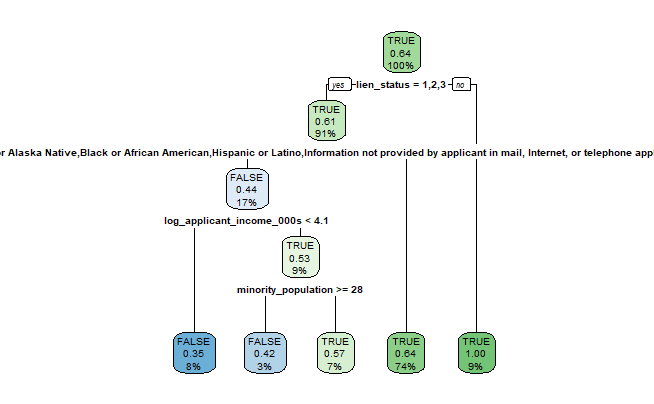

```r
library(rpart.plot)
rpart.plot(model_dt_loan_to_income_ratio, extra = 106)
```

# Predictions using dt.

```r
preds_dt <- predict(model_dt_loan_to_income_ratio, test, type = 'class')
```

```r
confusionMatrix(data=as.factor(preds_dt), test$loan_granted, positive = "TRUE")
```

```
Confusion Matrix and Statistics

          Reference
Prediction FALSE  TRUE
     FALSE  4176  2382
     TRUE  18940 39058

               Accuracy : 0.6697
                 95% CI : (0.6661, 0.6733)
    No Information Rate : 0.6419
    P-Value [Acc > NIR] : < 2.2e-16

                  Kappa : 0.1464

 Mcnemar's Test P-Value : < 2.2e-16

            Sensitivity : 0.9425
            Specificity : 0.1807
         Pos Pred Value : 0.6734
         Neg Pred Value : 0.6368
             Prevalence : 0.6419
         Detection Rate : 0.6050
   Detection Prevalence : 0.8984
      Balanced Accuracy : 0.5616

       'Positive' Class : TRUE
```

# R logistic regression stepAIC steps

```r
full_model <- glm(train$loan_granted~., data = train, family = binomial(link='logit'))
```

```
glm.fit: fitted probabilities numerically 0 or 1 occurred
```

```r
summary(full_model)
```

```
Call:
glm(formula = train$loan_granted ~ ., family = binomial(link = "logit"),
    data = train)

Deviance Residuals:
     Min        1Q    Median        3Q       Max
-2.53828  -0.53060   0.00004   0.72021   3.10669

Coefficients: (1 not defined because of singularities)
                                                                                                                Estimate
(Intercept)                                                                                                    1.977e+01
applicant_race_and_ethnicityAsian                                                                              6.937e-01
applicant_race_and_ethnicityBlack or African American                                                          2.288e-01
applicant_race_and_ethnicityHispanic or Latino                                                                 3.711e-01
applicant_race_and_ethnicityInformation not provided by applicant in mail, Internet, or telephone application  2.730e-01
applicant_race_and_ethnicityNative Hawaiian or Other Pacific Islander                                          4.245e-01
applicant_race_and_ethnicityNot applicable                                                                     1.491e-01
applicant_race_and_ethnicityWhite                                                                              8.003e-01
applicant_income_000s                                                                                         -2.951e-04
co_applicant_sex2                                                                                              2.368e-01
co_applicant_sex3                                                                                              1.914e-01
co_applicant_sex4                                                                                              2.226e-01
co_applicant_sex5                                                                                             -8.790e-02
county_code3                                                                                                   6.741e-01
county_code5                                                                                                   6.268e-01
county_code7                                                                                                   6.440e-01
county_code9                                                                                                   7.177e-01
county_code11                                                                                                  4.000e-01
county_code13                                                                                                 -1.452e-02
county_code15                                                                                                  5.232e-01
county_code17                                                                                                  8.162e-01
county_code19                                                                                                  9.138e-01
county_code21                                                                                                  5.056e-01
county_code23                                                                                                 -2.962e-01
county_code25                                                                                                 -1.084e-01
county_code27                                                                                                  1.302e+00
county_code29                                                                                                  8.041e-01
county_code31                                                                                                  3.939e-01
county_code33                                                                                                  4.645e-01
county_code35                                                                                                  4.854e-01
```

[output cut: 539 more lines]

```
minority_population                                                                                           ***
co_applicant_present1
White_Percent
log_loan_amount_000s                                                                                          ***
log_applicant_income_000s                                                                                     ***
---
Signif. codes:  0 ‘***’ 0.001 ‘**’ 0.01 ‘*’ 0.05 ‘.’ 0.1 ‘ ’ 1

(Dispersion parameter for binomial family taken to be 1)

    Null deviance: 336889  on 258228  degrees of freedom
Residual deviance: 181944  on 258116  degrees of freedom
AIC: 182170

Number of Fisher Scoring iterations: 18
```

```r
library(MASS)
aic_model <- full_model %>% stepAIC(trace = TRUE)
```

```
Start:  AIC=182170
train$loan_granted ~ applicant_race_and_ethnicity + applicant_income_000s +
    co_applicant_sex + county_code + hoepa_status + lien_status +
    msamd + owner_occupancy + preapproval + property_type + purchaser_type +
    loan_amount_000s + applicant_sex + hud_median_family_income +
    tract_to_msamd_income + loan_to_income_ratio + agency_code +
    minority_population + co_applicant_present + White_Percent +
    log_loan_amount_000s + log_applicant_income_000s
```

[output not shown]

# Comparing full and stepAIC models

```r
writeLines("")
```

```r
writeLines("Summary of full model is as below")
```

```
Summary of full model is as below
```

```r
writeLines("")
```

```r
summary(full_model)
```

```
Call:
glm(formula = train$loan_granted ~ ., family = binomial(link = "logit"),
    data = train)

Deviance Residuals:
     Min        1Q    Median        3Q       Max
-2.53828  -0.53060   0.00004   0.72021   3.10669

Coefficients: (1 not defined because of singularities)
                                                                                                                Estimate
(Intercept)                                                                                                    1.977e+01
applicant_race_and_ethnicityAsian                                                                              6.937e-01
applicant_race_and_ethnicityBlack or African American                                                          2.288e-01
applicant_race_and_ethnicityHispanic or Latino                                                                 3.711e-01
applicant_race_and_ethnicityInformation not provided by applicant in mail, Internet, or telephone application  2.730e-01
applicant_race_and_ethnicityNative Hawaiian or Other Pacific Islander                                          4.245e-01
applicant_race_and_ethnicityNot applicable                                                                     1.491e-01
applicant_race_and_ethnicityWhite                                                                              8.003e-01
applicant_income_000s                                                                                         -2.951e-04
co_applicant_sex2                                                                                              2.368e-01
co_applicant_sex3                                                                                              1.914e-01
co_applicant_sex4                                                                                              2.226e-01
co_applicant_sex5                                                                                             -8.790e-02
county_code3                                                                                                   6.741e-01
county_code5                                                                                                   6.268e-01
county_code7                                                                                                   6.440e-01
county_code9                                                                                                   7.177e-01
county_code11                                                                                                  4.000e-01
county_code13                                                                                                 -1.452e-02
county_code15                                                                                                  5.232e-01
county_code17                                                                                                  8.162e-01
county_code19                                                                                                  9.138e-01
county_code21                                                                                                  5.056e-01
county_code23                                                                                                 -2.962e-01
county_code25                                                                                                 -1.084e-01
county_code27                                                                                                  1.302e+00
county_code29                                                                                                  8.041e-01
county_code31                                                                                                  3.939e-01
county_code33                                                                                                  4.645e-01
county_code35                                                                                                  4.854e-01
```

[output cut: 539 more lines]

```
minority_population                                                                                           ***
co_applicant_present1
White_Percent
log_loan_amount_000s                                                                                          ***
log_applicant_income_000s                                                                                     ***
---
Signif. codes:  0 ‘***’ 0.001 ‘**’ 0.01 ‘*’ 0.05 ‘.’ 0.1 ‘ ’ 1

(Dispersion parameter for binomial family taken to be 1)

    Null deviance: 336889  on 258228  degrees of freedom
Residual deviance: 181944  on 258116  degrees of freedom
AIC: 182170

Number of Fisher Scoring iterations: 18
```

```r
writeLines("")
```

```r
writeLines("Summary of stepAIC model are as below")
```

```
Summary of stepAIC model are as below
```

```r
writeLines("")
```

```r
summary(aic_model)
```

```
Call:
glm(formula = train$loan_granted ~ applicant_race_and_ethnicity +
    applicant_income_000s + co_applicant_sex + county_code +
    hoepa_status + lien_status + msamd + owner_occupancy + preapproval +
    property_type + purchaser_type + applicant_sex + hud_median_family_income +
    tract_to_msamd_income + agency_code + minority_population +
    log_loan_amount_000s + log_applicant_income_000s, family = binomial(link = "logit"),
    data = train)

Deviance Residuals:
     Min        1Q    Median        3Q       Max
-2.54260  -0.53091   0.00004   0.71990   3.11413

Coefficients:
                                                                                                                Estimate
(Intercept)                                                                                                    1.970e+01
applicant_race_and_ethnicityAsian                                                                              6.930e-01
applicant_race_and_ethnicityBlack or African American                                                          2.299e-01
applicant_race_and_ethnicityHispanic or Latino                                                                 3.714e-01
applicant_race_and_ethnicityInformation not provided by applicant in mail, Internet, or telephone application  3.017e-01
applicant_race_and_ethnicityNative Hawaiian or Other Pacific Islander                                          4.234e-01
applicant_race_and_ethnicityNot applicable                                                                     1.707e-01
applicant_race_and_ethnicityWhite                                                                              7.993e-01
applicant_income_000s                                                                                         -2.881e-04
co_applicant_sex2                                                                                              2.360e-01
co_applicant_sex3                                                                                              2.516e-01
co_applicant_sex4                                                                                              2.834e-01
co_applicant_sex5                                                                                             -2.449e-02
county_code3                                                                                                   6.738e-01
county_code5                                                                                                   6.263e-01
county_code7                                                                                                   6.435e-01
county_code9                                                                                                   7.175e-01
county_code11                                                                                                  3.994e-01
county_code13                                                                                                 -1.419e-02
county_code15                                                                                                  5.230e-01
county_code17                                                                                                  8.152e-01
county_code19                                                                                                  9.135e-01
county_code21                                                                                                  5.059e-01
county_code23                                                                                                 -2.961e-01
county_code25                                                                                                 -1.082e-01
```

[output cut: 524 more lines]

```
agency_code7                                                                                                  ***
agency_code9                                                                                                  ***
minority_population                                                                                           ***
log_loan_amount_000s                                                                                          ***
log_applicant_income_000s                                                                                     ***
---
Signif. codes:  0 ‘***’ 0.001 ‘**’ 0.01 ‘*’ 0.05 ‘.’ 0.1 ‘ ’ 1

(Dispersion parameter for binomial family taken to be 1)

    Null deviance: 336889  on 258228  degrees of freedom
Residual deviance: 181946  on 258119  degrees of freedom
AIC: 182166

Number of Fisher Scoring iterations: 18
```